# Course Project 1

Martin Mason

9 August 2016

#### Loading the Document into R

```r
download.file("https://d396qusza40orc.cloudfront.net/repdata%2Fdata%2Factivity.zip", "activityData.zip", method="curl")
```

Then we unzip the data

```r
unzip("activityData.zip")
```

```r
myCSV <- read.csv("activity.csv", header = TRUE)
```

## What is the mean total number of steps taken per day?

First we create an array called stepsPerDay with the number of steps for each day

```r
stepsPerDay <- tapply(myCSV$steps, myCSV$date, sum, na.rm=TRUE)
```

Which give us the following array

```
## 2012-10-01 2012-10-02 2012-10-03 2012-10-04 2012-10-05 2012-10-06
##          0        126      11352      12116      13294      15420
## 2012-10-07 2012-10-08 2012-10-09 2012-10-10 2012-10-11 2012-10-12
##      11015          0      12811       9900      10304      17382
## 2012-10-13 2012-10-14 2012-10-15 2012-10-16 2012-10-17 2012-10-18
##      12426      15098      10139      15084      13452      10056
## 2012-10-19 2012-10-20 2012-10-21 2012-10-22 2012-10-23 2012-10-24
##      11829      10395       8821      13460       8918       8355
## 2012-10-25 2012-10-26 2012-10-27 2012-10-28 2012-10-29 2012-10-30
##       2492       6778      10119      11458       5018       9819
## 2012-10-31 2012-11-01 2012-11-02 2012-11-03 2012-11-04 2012-11-05
##      15414          0      10600      10571          0      10439
## 2012-11-06 2012-11-07 2012-11-08 2012-11-09 2012-11-10 2012-11-11
##       8334      12883       3219          0          0      12608
## 2012-11-12 2012-11-13 2012-11-14 2012-11-15 2012-11-16 2012-11-17
##      10765       7336          0         41       5441      14339
## 2012-11-18 2012-11-19 2012-11-20 2012-11-21 2012-11-22 2012-11-23
##      15110       8841       4472      12787      20427      21194
## 2012-11-24 2012-11-25 2012-11-26 2012-11-27 2012-11-28 2012-11-29
##      14478      11834      11162      13646      10183       7047
## 2012-11-30
##          0
```

This can in turn be represented as a histogram

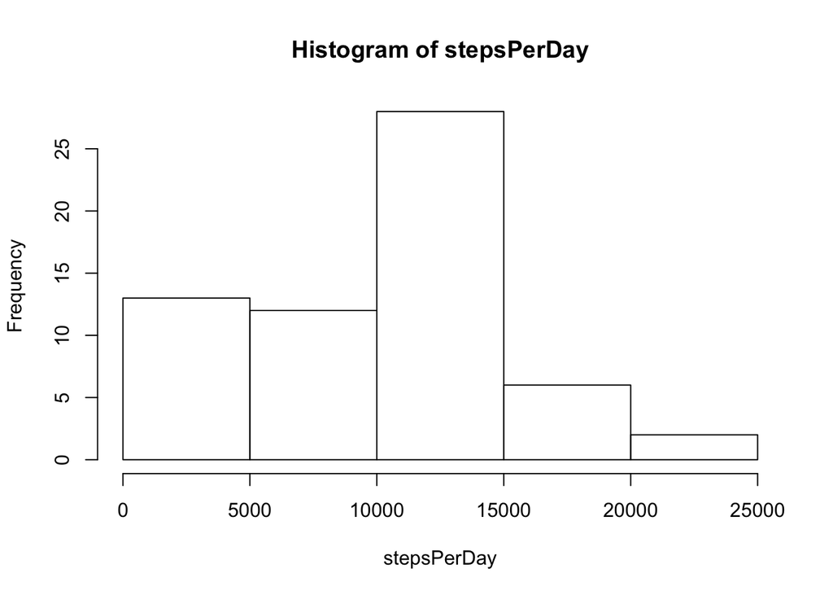

```r
hist(stepsPerDay)
```

The mean and median can be calculate in the following way

```r
myMedian <- median(stepsPerDay)
myMean <- mean(stepsPerDay)
```

This gives us a mean of 9354.2295082 and a median of 10395.

## What is the average daily activity pattern?

Here is the time-series plot:

[figure not shown]

```r
myData <- tapply(myCSV$steps, myCSV$interval, mean, na.rm=TRUE)
```

To find the 5 minute interval which was highest I did the following:

```r
highestInterval <-  names(myData[myData == max(myData)])
```

Returns the value 206.1698113, showing that it was in fact interval number 835.

## Inputing missing values

First we count the number of rows with NAs:

```r
NAs <- (!complete.cases(myCSV))
NAs <- NAs[NAs == TRUE]
NACount <- length(NAs)
return(NACount)
```

```
## [1] 2304
```

This means that the number of rows that are incomplete, e.g. contain NAs, is 2304.

#### Replacing NAs

First I want to check if there are NAs in other columns than simply the first one.

Here I check the ‘steps’ column for NAs:

```r
any(is.na(myCSV$steps))
```

```
## [1] TRUE
```

The TRUE indicates that there are some NAs in this column

Now I check the ‘date’ column:

```r
any(is.na(myCSV$date))
```

```
## [1] FALSE
```

The FALSE indicates that there are no NAs

Then I check the ‘interval’ column for NAs

```r
any(is.na(myCSV$interval))
```

```
## [1] FALSE
```

The FALSE value indicates that there are no NAs in this column

This means that all the the NAs that need replacing are in the steps column

#### Locating the NAs

First I’ll create an index to give me a way to identify the places where I need to replace a NA with a value

```r
index <- is.na(myCSV$steps)
```

Second, I’ll create a copy of the data called tidyValues:

```r
tidyValues <- myCSV
```

Thirdly, I need to calculate the means for each intervak, this will be what I replace the NAs with

```r
intervalMeans <- tapply(tidyValues$steps, tidyValues$interval, mean, na.rm=TRUE)
```

Now we need to create the code that replaces the NA value with the mean of the interval, using the index.

```r
for(i in 1:length(index)){
        if(index[i] == TRUE){
                tidyValues$steps[i] <- intervalMeans[paste(tidyValues$interval[i])]
        }
}
```

We can then double check that there no longer are any NAs by repeating the first test:

```r
any(is.na(tidyValues$steps))
```

```
## [1] FALSE
```

The FALSE indicates that there are no longer any NAs in the column.

#### Making a histogram

First we need to calculate the the number of steps for each day, then we display this information as a histogram.

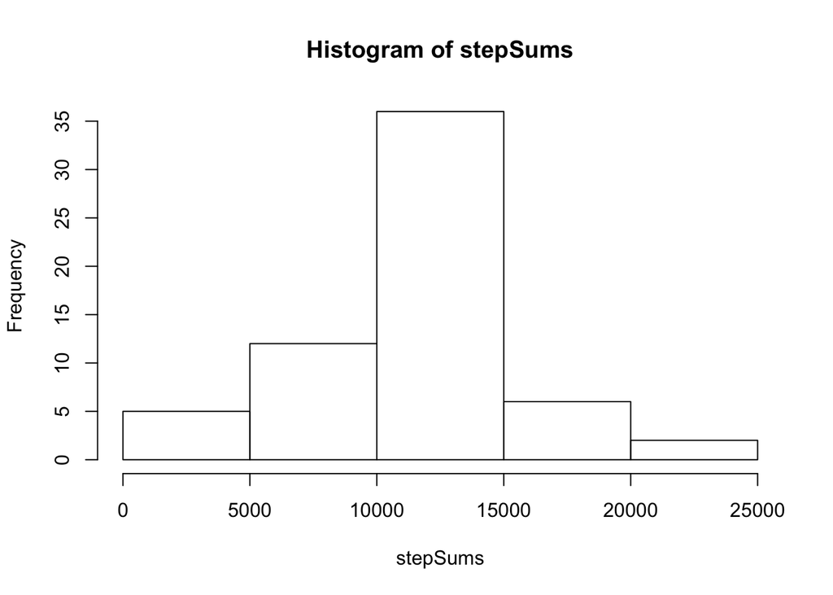

```r
stepSums <- tapply(tidyValues$steps, tidyValues$date, sum)
hist(stepSums)
```

The new histogram seems to indicate more of a normal distribution in the data.

Next we calculate the median and mean values:

```r
stepsPerDay
```

```
## 2012-10-01 2012-10-02 2012-10-03 2012-10-04 2012-10-05 2012-10-06
##          0        126      11352      12116      13294      15420
## 2012-10-07 2012-10-08 2012-10-09 2012-10-10 2012-10-11 2012-10-12
##      11015          0      12811       9900      10304      17382
## 2012-10-13 2012-10-14 2012-10-15 2012-10-16 2012-10-17 2012-10-18
##      12426      15098      10139      15084      13452      10056
## 2012-10-19 2012-10-20 2012-10-21 2012-10-22 2012-10-23 2012-10-24
##      11829      10395       8821      13460       8918       8355
## 2012-10-25 2012-10-26 2012-10-27 2012-10-28 2012-10-29 2012-10-30
##       2492       6778      10119      11458       5018       9819
## 2012-10-31 2012-11-01 2012-11-02 2012-11-03 2012-11-04 2012-11-05
##      15414          0      10600      10571          0      10439
## 2012-11-06 2012-11-07 2012-11-08 2012-11-09 2012-11-10 2012-11-11
##       8334      12883       3219          0          0      12608
## 2012-11-12 2012-11-13 2012-11-14 2012-11-15 2012-11-16 2012-11-17
##      10765       7336          0         41       5441      14339
## 2012-11-18 2012-11-19 2012-11-20 2012-11-21 2012-11-22 2012-11-23
##      15110       8841       4472      12787      20427      21194
## 2012-11-24 2012-11-25 2012-11-26 2012-11-27 2012-11-28 2012-11-29
##      14478      11834      11162      13646      10183       7047
## 2012-11-30
##          0
```

```r
stepSums
```

```
## 2012-10-01 2012-10-02 2012-10-03 2012-10-04 2012-10-05 2012-10-06
##   10766.19     126.00   11352.00   12116.00   13294.00   15420.00
## 2012-10-07 2012-10-08 2012-10-09 2012-10-10 2012-10-11 2012-10-12
##   11015.00   10766.19   12811.00    9900.00   10304.00   17382.00
## 2012-10-13 2012-10-14 2012-10-15 2012-10-16 2012-10-17 2012-10-18
##   12426.00   15098.00   10139.00   15084.00   13452.00   10056.00
## 2012-10-19 2012-10-20 2012-10-21 2012-10-22 2012-10-23 2012-10-24
##   11829.00   10395.00    8821.00   13460.00    8918.00    8355.00
## 2012-10-25 2012-10-26 2012-10-27 2012-10-28 2012-10-29 2012-10-30
##    2492.00    6778.00   10119.00   11458.00    5018.00    9819.00
## 2012-10-31 2012-11-01 2012-11-02 2012-11-03 2012-11-04 2012-11-05
##   15414.00   10766.19   10600.00   10571.00   10766.19   10439.00
## 2012-11-06 2012-11-07 2012-11-08 2012-11-09 2012-11-10 2012-11-11
##    8334.00   12883.00    3219.00   10766.19   10766.19   12608.00
## 2012-11-12 2012-11-13 2012-11-14 2012-11-15 2012-11-16 2012-11-17
##   10765.00    7336.00   10766.19      41.00    5441.00   14339.00
## 2012-11-18 2012-11-19 2012-11-20 2012-11-21 2012-11-22 2012-11-23
##   15110.00    8841.00    4472.00   12787.00   20427.00   21194.00
## 2012-11-24 2012-11-25 2012-11-26 2012-11-27 2012-11-28 2012-11-29
##   14478.00   11834.00   11162.00   13646.00   10183.00    7047.00
## 2012-11-30
##   10766.19
```

```r
newMean <- mean(stepSums)
newMedian <- median(stepSums)
newMean
```

```
## [1] 10766.19
```

```r
newMedian
```

```
## [1] 10766.19
```

The data containing NAs gave us a mean of 9354.2295082 and a median of 10395. The data with NAs replaced gave us the same mean and median value; 10766.19. This seems odd to me because the distribution does not look lika a perfect normal distribution, which I think it would have to be for this result to be true.

#### Weekday assignment

First we assign the day of the week to a separate vector and add it to our dataset:

```r
weekday <- weekdays(as.Date(tidyValues$date))
tidyValues <- cbind(tidyValues, weekday)
```

Now we assign all saturdays and sundays to weekend and the rest as weekdays by first creating an with the same contents as weekday:

```r
dayCategory <- weekday
```

```r
wordSwapper <- function(x){
        if(x == "Saturday"|"Sunday" == TRUE){
                x <- "weekend"
        }
        else{
                x <- "weekday"
        }
}
```

I then use sapply to iterate over the dayCategory and columnbind this to the dataset. This is done to maintain the granularity of the data, so that we can always go back and check for each day should we want to.

```r
dayCategory <- sapply(dayCategory, wordSwapper)
tidyValues <- cbind(tidyValues, dayCategory)
```

### Plot

First we load the dplyr package.

```r
library(dplyr)
```

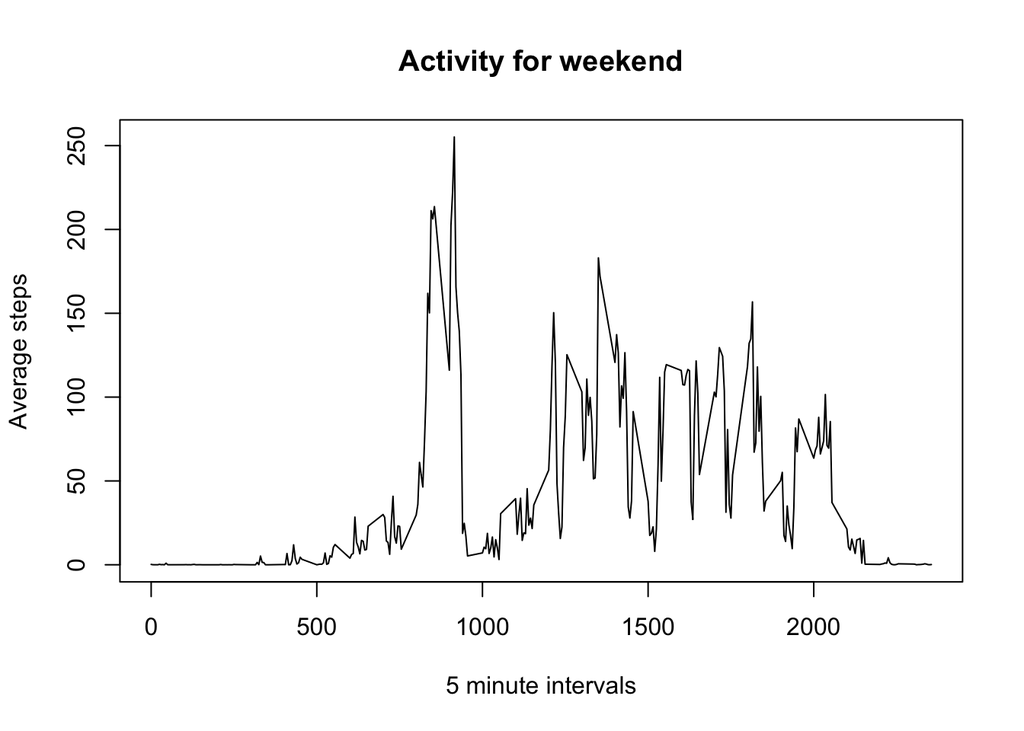

[figure not shown]

```r
tidyWeekend <- tbl_df(tidyValues)
tidyWeekend <- filter(tidyValues, dayCategory == "weekend")
plot(unique(tidyWeekend$interval), tapply(tidyWeekend$steps, tidyWeekend$interval, mean, na.rm=TRUE), type="l",  main = "Activity for weekend",xlab = "5 minute intervals", ylab ="Average steps")
```